# Collective Nature of Prejudice Revision

# Study 1a and 1b

## Similarity between subsamples, Problems with Median Split

Reviewer 1 writes:

*“I found myself struggling with the analytic strategy the authors employed for Studies 1 and 2. The problem with median splits is well known: they draw an artificial distinction between participants who aren’t actually very different, and lump together participants who are actually pretty different from one another. For example, a participant with an SDO score just above the median is more similar to a participant with an SDO score just below the median than they are to a participant with an extremely high SDO score, but the median split process separates the similar participants and forces the more dissimilar participants into the same category. Off the top of my head I don’t have a better analytic strategy to suggest, but I would have a lot more confidence in these findings if they demonstrated the same conceptual pattern of results without relying on median splits.”*

To address this critique, we could implement multiple splitting thresholds. While the resulting groups would still be somewhat arbitrary, this approach would at least prevent extreme cases—such as participants with RWA scores of 1.0 and 1.9 being assigned to the same group, while someone with a score of 2.1 is placed in the “high” subsample. Specifically, I considered performing several splits: a median split, as well as additional splits at the 40th/60th, 30th/70th, 20th/80th, and 10th/90th percentiles.

### Study 1a

Here you see what is happening:

```r
splits_1a <-
  ds1 %>%
  select(case,rwa,sdo,all_of(trgt.itms.1a)) %>%
  pivot_longer(cols = all_of(trgt.itms.1a),
               names_to = "target",
               values_to = "rating") %>%
  #THIS IS THE IMPORTANT PART: SPLITTING THE SAMPLE
  mutate(split_med = case_when(rwa > quantile(rwa,0.5,na.rm = T,names = F) ~ "high",
                               rwa < quantile(rwa,0.5,na.rm = T,names = F) ~ "low"),
         split_46 =  case_when(rwa > quantile(rwa,0.6,na.rm = T,names = F) ~ "high",
                               rwa < quantile(rwa,0.4,na.rm = T,names = F) ~ "low"),
         split_37 =  case_when(rwa > quantile(rwa,0.7,na.rm = T,names = F) ~ "high",
                               rwa < quantile(rwa,0.3,na.rm = T,names = F) ~ "low"),
         split_28 =  case_when(rwa > quantile(rwa,0.8,na.rm = T,names = F) ~ "high",
                               rwa < quantile(rwa,0.2,na.rm = T,names = F) ~ "low"),
         split_19 =  case_when(rwa > quantile(rwa,0.9,na.rm = T,names = F) ~ "high",
                               rwa < quantile(rwa,0.1,na.rm = T,names = F) ~ "low")) %>%
  pivot_longer(cols = starts_with("split"),
               names_to = "split",
               values_to = "subgroup") %>%
  group_by(target,split,subgroup) %>%
  summarise(prj_mean = mean(rating,na.rm = T)) %>%
  filter(!is.na(subgroup)) %>%
  pivot_wider(names_from = "subgroup",
              values_from = "prj_mean") %>%
  mutate(diff = abs(high-low),
         split_num = case_when(split == "split_med" ~ 0,
                               split == "split_46" ~ 1,
                               split == "split_37" ~ 2,
                               split == "split_28" ~ 3,
                               split == "split_19" ~ 4),
         target = str_remove_all(target,"prj_"),
         target = str_to_title(str_replace_all(target,"_"," "))) %>%
  ungroup()
```

**Plotting the absolute difference values for each target by split**

Higher split values indicate the difference in RWA between subsamples, so the higher the split value the more distance (in units on the RWA scale) is between the subgroups.

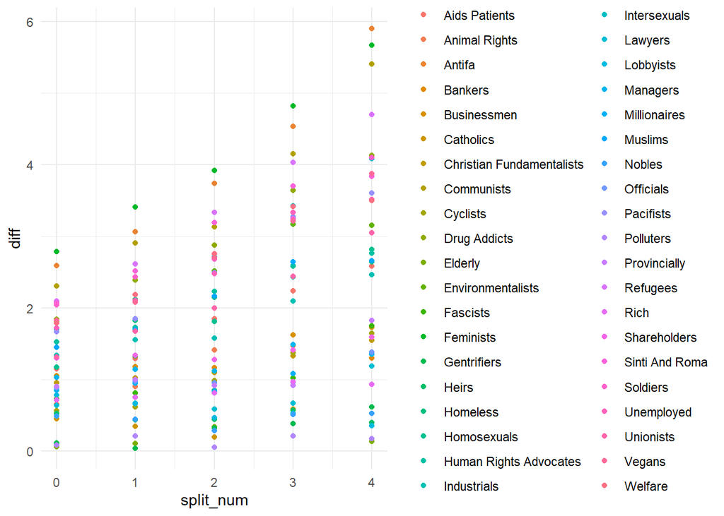

Descripively, we see that the difference between prejudice means increases with increasing differences in RWA. Although, there are still targets that seem to be highly consensual.

**Correlation across all sample splits**

```r
splits_1a %>%
  select(high,low) %>%
  correlation::correlation()
```

```
# Correlation Matrix (pearson-method)

Parameter1 | Parameter2 |    r |       95% CI | t(198) |         p
------------------------------------------------------------------
high       |        low | 0.51 | [0.40, 0.61] |   8.38 | < .001***

p-value adjustment method: Holm (1979)
Observations: 200
```

Correlation across all subsample splits is *r* = **0.512**. As we would expect, this is lower than the ~ .80 that we had before, when we only conduct the median split. In this sense, this approach may be a more strict test.

However, we can also compute the correlation for each single split:

```
# Correlation Matrix (pearson-method)

Group     | Parameter1 | Parameter2 |    r |        95% CI | t(38) |         p
------------------------------------------------------------------------------
split_19  |       high |        low | 0.18 | [-0.14, 0.46] |  1.10 | 0.280
split_28  |       high |        low | 0.41 | [ 0.11, 0.64] |  2.78 | 0.008**
split_37  |       high |        low | 0.59 | [ 0.35, 0.76] |  4.55 | < .001***
split_46  |       high |        low | 0.69 | [ 0.48, 0.82] |  5.85 | < .001***
split_med |       high |        low | 0.78 | [ 0.62, 0.88] |  7.73 | < .001***

p-value adjustment method: Holm (1979)
Observations: 40
```

### Study 1b

Now the same approach for Study 1b.

**Plotting the absolute difference values for each target by split**

Higher split values indicate the difference in RWA between subsamples, so the higher the split value the more distance (in units on the RWA scale) is between the subgroups.

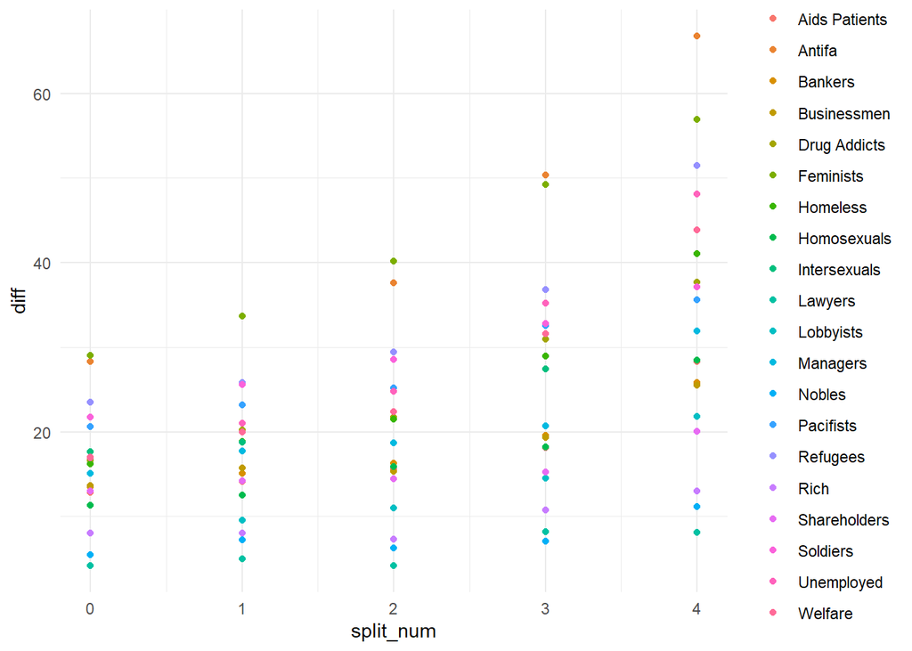

Descripively, we see that the difference between prejudice means increases with increasing differences in RWA. Although, there are still targets that seem to be highly consensual.

**Correlation across all sample splits**

```r
splits_1b %>%
  select(high,low) %>%
  correlation::correlation()
```

```
# Correlation Matrix (pearson-method)

Parameter1 | Parameter2 |    r |        95% CI | t(98) |     p
--------------------------------------------------------------
high       |        low | 0.03 | [-0.17, 0.23] |  0.30 | 0.766

p-value adjustment method: Holm (1979)
Observations: 100
```

Correlation across all subsample splits is *r* = **0.03**. Wow, this is a low correlation.

However, we can have a closer look and compute the correlation for each single split:

```
# Correlation Matrix (pearson-method)

Group     | Parameter1 | Parameter2 |     r |         95% CI | t(18) |      p
-----------------------------------------------------------------------------
split_19  |       high |        low | -0.49 | [-0.77, -0.06] | -2.38 | 0.028*
split_28  |       high |        low | -0.13 | [-0.54,  0.33] | -0.56 | 0.580
split_37  |       high |        low |  0.24 | [-0.22,  0.62] |  1.07 | 0.300
split_46  |       high |        low |  0.36 | [-0.09,  0.69] |  1.66 | 0.114
split_med |       high |        low |  0.54 | [ 0.13,  0.79] |  2.73 | 0.014*

p-value adjustment method: Holm (1979)
Observations: 20
```

Ok, here we see that prejudices are actually negatively correlated, when we for instance correlate the mean values from the lower RWA 10% decile and the higher RWA 90% decile.

## Variance decomposition

Reviewer 2 writes:

*“The multilevel modeling results reported by the authors show that 20–30% of the total variance is observable on the target-level, whereas RWA/SDO explain only 7–12% of the variance between respondents. The authors then argue that target-level differences account for the largest share of the variance. This comparison is problematic, however, because the respondent-level estimate reflects variance explained by predictors (RWA/SDO), while the target-level estimate reflects observed variance. I do not think the approach proposed by Rights and Sterba (2019) is appropriate here. A more suitable comparison would involve computing the ICC after restructuring the data with targets nested within respondents. This would likely show that more variance is obervable on the respondent-level than at the target-level, contradicting the authors’ interpretation. Another useful approach would be variance decomposition as applied by Koch et al. (2020), which the authors cite. This would partition the variance into group variance (consensual differences between targets), rater variance (differences between respondents in their overall prejudice), and group × rater variance (non-consensual differences between targets). The limitation, however, is that this approach cannot disentangle error variance from the group × rater variance.”*

### Nested Target approach

*I do not think the approach proposed by Rights and Sterba (2019) is appropriate here. A more suitable comparison would involve computing the ICC after restructuring the data with targets nested within respondents. This would likely show that more variance is obervable on the respondent-level than at the target-level, contradicting the authors’ interpretation.*

As far as I undestand it the reviewer describes the model like this: `(prejudice rating ~ 1 + (1|case/target)` where targets are nested within participants (case). However, such a model is not possible with our data since we have only one target rating per participant. Hence, the model *target nested within participant* is fully identified and as a result, there is no variance at the target:participant level. I belief that the reviewer is from the Koch et al. group, because she/he suggests things that they did with two measures within participant

### Koch et al. (2020) approach

*Another useful approach would be variance decomposition as applied by Koch et al. (2020), which the authors cite. This would partition the variance into group variance (consensual differences between targets), rater variance (differences between respondents in their overall prejudice), and group × rater variance (non-consensual differences between targets). The limitation, however, is that this approach cannot disentangle error variance from the group × rater variance.*

Below you find the Koch et al (2020) approach. However, else than Koch et al., we cannot model the target x person interaction because we would need at least two measures of each target within participant. Therefore, the formula is `prejudice ~ 1 + (1 | case) + (1 | target)`.

#### Study 1a

##### Model 1: Random effects for Participants and Targets

Data is in long format:

```r
head(var_decomp_1a)
```

```
# A tibble: 6 × 5
  case     rwa   sdo target                    rating
  <chr>  <dbl> <dbl> <fct>                      <dbl>
1 case14  2.89  2.25 rich                           5
2 case14  2.89  2.25 christian_fundamentalists      7
3 case14  2.89  2.25 catholics                      6
4 case14  2.89  2.25 fascists                       9
5 case14  2.89  2.25 lawyers                        2
6 case14  2.89  2.25 soldiers                       8
```

**Fitting the model:**

```r
mod_a_1a = lmer(rating ~ 1 + (1|case) + (1|target), data = var_decomp_1a)
summary(mod_a_1a)
```

```
Linear mixed model fit by REML ['lmerMod']
Formula: rating ~ 1 + (1 | case) + (1 | target)
   Data: var_decomp_1a

REML criterion at convergence: 96729

Scaled residuals:
    Min      1Q  Median      3Q     Max
-4.2897 -0.6731 -0.0317  0.6353  3.8996

Random effects:
 Groups   Name        Variance Std.Dev.
 case     (Intercept) 1.680    1.296
 target   (Intercept) 3.173    1.781
 Residual             5.382    2.320
Number of obs: 21039, groups:  case, 541; target, 40

Fixed effects:
            Estimate Std. Error t value
(Intercept)   5.7152     0.2876   19.87
```

Descriptively, we see that the variance within target is much bigger than variance within participant.

**Calculating the ICCs for each random effect:**

`icc case <- var_case / (var_case + var_target + var_residual)`

`icc target <- var_target / (var_case + var_target + var_residual)`

| Random.effect | ICC |
| --- | --- |
| Participant | 0.1641742 |
| Target | 0.3100199 |

```r
performance::icc(mod_a_1a)
```

```
# Intraclass Correlation Coefficient

    Adjusted ICC: 0.474
  Unadjusted ICC: 0.474
```

The ICC of the participant (Variance explained by clustering variable participant) is 0.1642, the ICC of target (variance explained by clustering variable target) is 0.31.

##### Model 2: Fixed effects RWA, SDO, Random effects Participants and Targets

Now adding RWA and SDO as fixed effects

```r
mod_rwasdo_1a = lmer(rating ~ rwa + sdo + (1|case) + (1|target), data = var_decomp_1a)
summary(mod_rwasdo_1a)
```

```
Linear mixed model fit by REML ['lmerMod']
Formula: rating ~ rwa + sdo + (1 | case) + (1 | target)
   Data: var_decomp_1a

REML criterion at convergence: 96685.3

Scaled residuals:
    Min      1Q  Median      3Q     Max
-4.2982 -0.6733 -0.0308  0.6368  3.8709

Random effects:
 Groups   Name        Variance Std.Dev.
 case     (Intercept) 1.525    1.235
 target   (Intercept) 3.172    1.781
 Residual             5.382    2.320
Number of obs: 21039, groups:  case, 541; target, 40

Fixed effects:
            Estimate Std. Error t value
(Intercept)  4.51624    0.33576  13.451
rwa          0.21714    0.09297   2.336
sdo          0.35079    0.07878   4.453

Correlation of Fixed Effects:
    (Intr) rwa
rwa -0.311
sdo -0.177 -0.548
```

**Calculating the ICCs for each random effect:**

| Random.effect | ICC |
| --- | --- |
| Participant | 0.1513277 |
| Target | 0.3147355 |

```r
# performance
performance::icc(mod_rwasdo_1a)
```

```
# Intraclass Correlation Coefficient

    Adjusted ICC: 0.466
  Unadjusted ICC: 0.459
```

```r
performance::r2(mod_rwasdo_1a)
```

```
# R2 for Mixed Models

  Conditional R2: 0.475
     Marginal R2: 0.016
```

The ICCs remain high even if we introduce fixed effects. The Marginal R<sup>2</sup> shows that even if we include RWA and SDO as predictors, the much bigger proportion of variance is explained by random effects.

##### Model 3: Random effects for Participants, Targets, RWA subsamples

Random effects within high vs low RWA / SDO individuals

Added 2 new variables that cluster participants (1) along the median split in the high vs. low sample and (2) along the +1 SD in RWA subsample and -1 SD in RWA subsample, respectively. Have a look:

```r
head(var_decomp_1a)
```

```
# A tibble: 6 × 7
  case     rwa   sdo target                   rating rwa_med_split rwa_1sd_split
  <chr>  <dbl> <dbl> <fct>                     <dbl> <chr>         <chr>
1 case14  2.89  2.25 rich                          5 high          +1sd
2 case14  2.89  2.25 christian_fundamentalis…      7 high          +1sd
3 case14  2.89  2.25 catholics                     6 high          +1sd
4 case14  2.89  2.25 fascists                      9 high          +1sd
5 case14  2.89  2.25 lawyers                       2 high          +1sd
6 case14  2.89  2.25 soldiers                      8 high          +1sd
```

Now building the new models with specified random effects within the subgroups

```r
mod_b_1a = lmer(rating ~ 1 + (1|case) + (1|target) + (1|rwa_med_split) + (1|rwa_1sd_split), data = var_decomp_1a)
summary(mod_b_1a)
```

```
Linear mixed model fit by REML ['lmerMod']
Formula: rating ~ 1 + (1 | case) + (1 | target) + (1 | rwa_med_split) +
    (1 | rwa_1sd_split)
   Data: var_decomp_1a

REML criterion at convergence: 31435.7

Scaled residuals:
    Min      1Q  Median      3Q     Max
-3.7881 -0.6878 -0.0292  0.6653  3.3831

Random effects:
 Groups        Name        Variance Std.Dev.
 case          (Intercept) 1.7482   1.3222
 target        (Intercept) 2.6243   1.6200
 rwa_med_split (Intercept) 0.3398   0.5829
 rwa_1sd_split (Intercept) 0.2679   0.5176
 Residual                  6.3785   2.5256
Number of obs: 6577, groups:
case, 169; target, 40; rwa_med_split, 2; rwa_1sd_split, 2

Fixed effects:
            Estimate Std. Error t value
(Intercept)   5.9124     0.6171   9.581
```

**Calculating the ICCs for each random effect:**

| Random.effect | ICC |
| --- | --- |
| Participant | 0.1626060 |
| Target | 0.2310412 |
| RWA Median Split Subsamples | 0.0299120 |
| RWA +-1SD Subsamples | 0.0235846 |

```r
# performance
performance::icc(mod_b_1a)
```

```
# Intraclass Correlation Coefficient

    Adjusted ICC: 0.438
  Unadjusted ICC: 0.438
```

```r
performance::r2(mod_b_1a)
```

```
# R2 for Mixed Models

  Conditional R2: 0.438
     Marginal R2: 0.000
```

What we see is that the (arbitrary) cluster of sample splits (high / low RWA) explain almost no variance in our DV (prejudice). Hence, it seems not meaningful to distinguish between high / low RWA subsamples.

##### Model 4: Prejudice mean centered prejudice targets

Each prejudice target was mean centered (mean centered for every prejudice target separately, NOT at the mean across all prejudice targets).

Have a look at the data:

```r
head(var_decompc_1a)
```

```
# A tibble: 6 × 5
  case     rwa   sdo target                    mc_rating
  <chr>  <dbl> <dbl> <fct>                         <dbl>
1 case14  2.89  2.25 rich                        -0.590
2 case14  2.89  2.25 christian_fundamentalists   -2.35
3 case14  2.89  2.25 catholics                   -0.0913
4 case14  2.89  2.25 fascists                    -1.34
5 case14  2.89  2.25 lawyers                     -3.07
6 case14  2.89  2.25 soldiers                     1.79
```

**Fitting the model:**

```r
mod_amc_1a = lmer(mc_rating ~ 1 + (1|case) + (1|target), data = var_decompc_1a)
summary(mod_amc_1a)
```

```
Linear mixed model fit by REML ['lmerMod']
Formula: mc_rating ~ 1 + (1 | case) + (1 | target)
   Data: var_decompc_1a

REML criterion at convergence: 96466.3

Scaled residuals:
    Min      1Q  Median      3Q     Max
-4.3071 -0.6746 -0.0315  0.6380  3.9073

Random effects:
 Groups   Name        Variance  Std.Dev.
 case     (Intercept) 1.680e+00 1.2962994
 target   (Intercept) 3.808e-07 0.0006171
 Residual             5.371e+00 2.3176372
Number of obs: 21039, groups:  case, 541; target, 40

Fixed effects:
            Estimate Std. Error t value
(Intercept) 0.006474   0.058075   0.111
optimizer (nloptwrap) convergence code: 0 (OK)
Model failed to converge with max|grad| = 0.0537736 (tol = 0.002, component 1)
```

Now, for mean centered prejudice targets. The model has convergence problems. We see that the target variance is smaller (of course, we removed it). Only the variance within participant and residual remains. Between target variance is important.

**Calculating the ICCs for each random effect:**

| Random.effect | ICC |
| --- | --- |
| Participant | 0.2382915 |
| Target | 0.0000001 |

```r
#performance
performance::icc(mod_amc_1a)
```

```
[1] NA
```

#### Study 1b

##### Model 1: Random effects for Participants and Targets

Data is in long format:

```r
head(var_decomp_1b)
```

```
# A tibble: 6 × 5
  case     rwa   sdo target      rating
  <chr>  <dbl> <dbl> <fct>        <dbl>
1 case48  2.33  4.62 businessmen    -23
2 case48  2.33  4.62 managers        -1
3 case48  2.33  4.62 soldiers        11
4 case48  2.33  4.62 bankers          6
5 case48  2.33  4.62 lobbyists        6
6 case48  2.33  4.62 lawyers        -39
```

**Fitting the model:**

```r
mod_a_1b = lmer(rating ~ 1 + (1|case) + (1|target), data = var_decomp_1b)
summary(mod_a_1b)
```

```
Linear mixed model fit by REML ['lmerMod']
Formula: rating ~ 1 + (1 | case) + (1 | target)
   Data: var_decomp_1b

REML criterion at convergence: 77982.2

Scaled residuals:
    Min      1Q  Median      3Q     Max
-3.9683 -0.6672 -0.0290  0.6602  3.2352

Random effects:
 Groups   Name        Variance Std.Dev.
 case     (Intercept) 144.9    12.04
 target   (Intercept) 179.1    13.38
 Residual             509.9    22.58
Number of obs: 8496, groups:  case, 432; target, 20

Fixed effects:
            Estimate Std. Error t value
(Intercept)  -39.122      3.058  -12.79
```

**Calculating the ICCs for each random effect:**

| Random.effect | ICC |
| --- | --- |
| Participant | 0.1737500 |
| Target | 0.2147493 |

```r
# ICC full model
performance::icc(mod_a_1b)
```

```
# Intraclass Correlation Coefficient

    Adjusted ICC: 0.388
  Unadjusted ICC: 0.388
```

The ICC of the participant (Variance explained by clustering variable participant) is 0.1738, the ICC of target (variance explained by clustering variable target) is 0.2147.

##### Model 2: Fixed effects RWA, SDO, Random effects Participants and Targets

Now adding RWA and SDO as fixed effects

```r
mod_rwasdo_1b = lmer(rating ~ rwa + sdo + (1|case) + (1|target), data = var_decomp_1b)
summary(mod_rwasdo_1b)
```

```
Linear mixed model fit by REML ['lmerMod']
Formula: rating ~ rwa + sdo + (1 | case) + (1 | target)
   Data: var_decomp_1b

REML criterion at convergence: 77933.6

Scaled residuals:
    Min      1Q  Median      3Q     Max
-4.0203 -0.6719 -0.0262  0.6600  3.2389

Random effects:
 Groups   Name        Variance Std.Dev.
 case     (Intercept) 128.3    11.33
 target   (Intercept) 179.0    13.38
 Residual             509.9    22.58
Number of obs: 8496, groups:  case, 432; target, 20

Fixed effects:
            Estimate Std. Error t value
(Intercept) -51.1993     3.5687 -14.347
rwa           2.7715     1.0695   2.591
sdo           2.9123     0.8082   3.604

Correlation of Fixed Effects:
    (Intr) rwa
rwa -0.344
sdo -0.106 -0.597
```

**Calculating the ICCs for each random effect:**

| Random.effect | ICC |
| --- | --- |
| Participant | 0.1570132 |
| Target | 0.2190655 |

```r
# performance
performance::icc(mod_rwasdo_1b)
```

```
# Intraclass Correlation Coefficient

    Adjusted ICC: 0.376
  Unadjusted ICC: 0.368
```

```r
performance::r2(mod_rwasdo_1b)
```

```
# R2 for Mixed Models

  Conditional R2: 0.389
     Marginal R2: 0.021
```

The ICCs remain high even if we introduce fixed effects. The Marginal R<sup>2</sup> shows that even if we include RWA and SDO as predictors, the much bigger proportion of variance is explained by random effects.

##### Model 3: Random effects for Participants, Targets, RWA subsamples

Random effects within high vs low RWA / SDO individuals

Added 2 new variables that cluster participants (1) along the median split in the high vs. low sample and (2) along the +1 SD in RWA subsample and -1 SD in RWA subsample, respectively. Have a look:

```r
head(var_decomp_1b)
```

```
# A tibble: 6 × 7
  case     rwa   sdo target      rating rwa_med_split rwa_1sd_split
  <chr>  <dbl> <dbl> <fct>        <dbl> <chr>         <chr>
1 case51  1.33  1.69 businessmen    -39 low           -1sd
2 case51  1.33  1.69 managers       -39 low           -1sd
3 case51  1.33  1.69 soldiers       -40 low           -1sd
4 case51  1.33  1.69 bankers        -41 low           -1sd
5 case51  1.33  1.69 lobbyists      -42 low           -1sd
6 case51  1.33  1.69 lawyers        -42 low           -1sd
```

Now building the new models with specified random effects within the subgroups

```r
mod_b_1b = lmer(rating ~ 1 + (1|case) + (1|target) + (1|rwa_med_split) + (1|rwa_1sd_split), data = var_decomp_1b)
summary(mod_b_1b)
```

```
Linear mixed model fit by REML ['lmerMod']
Formula: rating ~ 1 + (1 | case) + (1 | target) + (1 | rwa_med_split) +
    (1 | rwa_1sd_split)
   Data: var_decomp_1b

REML criterion at convergence: 23945.4

Scaled residuals:
    Min      1Q  Median      3Q     Max
-3.3558 -0.6953  0.0045  0.7135  2.5212

Random effects:
 Groups        Name        Variance Std.Dev.
 case          (Intercept) 111.02   10.537
 target        (Intercept) 128.04   11.316
 rwa_med_split (Intercept)  55.98    7.482
 rwa_1sd_split (Intercept)  11.50    3.391
 Residual                  666.73   25.821
Number of obs: 2537, groups:
case, 129; target, 20; rwa_med_split, 2; rwa_1sd_split, 2

Fixed effects:
            Estimate Std. Error t value
(Intercept)  -34.822      6.424   -5.42
optimizer (nloptwrap) convergence code: 0 (OK)
Model is nearly unidentifiable: large eigenvalue ratio
 - Rescale variables?
```

**Calculating the ICCs for each random effect:**

| Random.effect | ICC |
| --- | --- |
| Participant | 0.1225683 |
| Target | 0.1315584 |
| RWA Median Split Subsamples | 0.0575192 |
| RWA +-1SD Subsamples | 0.0118167 |

```r
# ICC full model
performance::icc(mod_b_1b)
```

```
# Intraclass Correlation Coefficient

    Adjusted ICC: 0.315
  Unadjusted ICC: 0.315
```

Again, what we see is that the (arbitrary) cluster of sample splits (high / low RWA) explain almost no variance in our DV (prejudice). Hence, it seems not meaningful to distinguish between high / low RWA subsamples.

# Study 2

## Critique of median split, ICCs at each level

Reviewer 2 writes:

*“Study 2: I missed the calculation of ICCs for all respondent-level variables. This would provide a clearer picture of how much variance actually can be observed at the country-level. While the results demonstrate that social context matters, I am not convinced they substantiate the claim that social context is more important than individual-difference variables.”*

I ran into problems of the multilevel model when I z-standardized all prejudice targets, because, with z-std targets some variance components became (become) 0. Therefore, I decided to apply **linear rescaling** to bring all targets on the same scale. Hence, all targets are then on a 1 (min) - 11 (max) scale. See below.

Preparing the data:

```r
rescale_linear <- function(x, old_min, old_max, new_min, new_max) {
  ( (x - old_min) / (old_max - old_min) ) * (new_max - new_min) + new_min
}

ess4_mlm <-
  ess4 %>%
  select(idno,
         trd,
         region,
         cntry_cde,
         starts_with("prj_") #all 6 prejudice targets
         ) %>%
  mutate(
    trd = as.numeric(scale(trd)), #standardize traditionalism
    idno = paste0(cntry_cde,idno),#participant identifier
    prj_homosexuals = as.numeric(prj_homosexuals),
    prj_homosexuals = rescale_linear(prj_homosexuals, old_min = 1,old_max = 5,new_min = 1, new_max = 11), #rescale anti gay prejudice
    prj_unemployed  = rescale_linear(prj_unemployed,  old_min = 1,old_max = 5,new_min = 1, new_max = 11), #rescale unemployed prejudice
    prj_women       = rescale_linear(prj_women,       old_min = 1,old_max = 5,new_min = 1, new_max = 11), #rescale anti women prejudice
    trd_1sd_split   = case_when( #creating  +-1SD in traditionalism subsamples
      trd >  1 ~ "+1SD",
      trd < -1 ~ "-1SD",
      TRUE ~ NA
    )
         )

#data to long format
ess4_mlm <-
  ess4_mlm %>%
  pivot_longer(cols = starts_with("prj_"),
               names_to = "target",
               values_to = "prejudice")
```

Have a look at the data:

```r
head(ess4_mlm)
```

```
# A tibble: 6 × 7
  idno      trd region         cntry_cde trd_1sd_split target          prejudice
  <chr>   <dbl> <chr>          <fct>     <chr>         <chr>               <dbl>
1 BE10202 -1.20 Flemish region BE        -1SD          prj_homosexuals      8.5
2 BE10202 -1.20 Flemish region BE        -1SD          prj_immigrants       5.67
3 BE10202 -1.20 Flemish region BE        -1SD          prj_unemployed       6
4 BE10202 -1.20 Flemish region BE        -1SD          prj_women            6
5 BE10202 -1.20 Flemish region BE        -1SD          prj_people20         6
6 BE10202 -1.20 Flemish region BE        -1SD          prj_people70         6
```

### Koch et al. approach: Looking at the ICCs of each cluster

First, fitting a simple model with all clusters as random effects, then having a look at the ICCs.

#### Model 1: Region and Target as Random Effects

First model looks like this: `prejudice ~ 1 + (1|region) + (1|target)`. This does not contain the countries, to see what happens later, when we add them.

```r
mlm_s2_m1 <- lmer(prejudice ~ 1 + (1|region) + (1|target), data = ess4_mlm)
summary(mlm_s2_m1)
```

```
Linear mixed model fit by REML ['lmerMod']
Formula: prejudice ~ 1 + (1 | region) + (1 | target)
   Data: ess4_mlm

REML criterion at convergence: 1531805

Scaled residuals:
    Min      1Q  Median      3Q     Max
-2.7845 -0.7237 -0.0868  0.7047  3.6763

Random effects:
 Groups   Name        Variance Std.Dev.
 region   (Intercept) 0.3898   0.6244
 target   (Intercept) 1.3288   1.1527
 Residual             5.8805   2.4250
Number of obs: 332096, groups:  region, 250; target, 6

Fixed effects:
            Estimate Std. Error t value
(Intercept)   4.9717     0.4723   10.53
```

```r
performance::icc(mlm_s2_m1)
```

```
# Intraclass Correlation Coefficient

    Adjusted ICC: 0.226
  Unadjusted ICC: 0.226
```

| Random.effect | ICC |
| --- | --- |
| Region | 0.0513015 |
| Target | 0.1748642 |

We see that the clustering variable *prejudice target* explaines the most variance in our DV prejudice. The variance explained by *prejudice target* is much bigger than the variance explained by region.

#### Model 2: Country, Region and Target as Random Effects

Second model looks like this: `prejudice ~ 1 + (1|country) + (1|region) + (1|target)`. Now with country added but no nesting.

```r
mlm_s2_m2 <- lmer(prejudice ~ 1 + (1|cntry_cde) + (1|region) + (1|target), data = ess4_mlm)
summary(mlm_s2_m2)
```

```
Linear mixed model fit by REML ['lmerMod']
Formula: prejudice ~ 1 + (1 | cntry_cde) + (1 | region) + (1 | target)
   Data: ess4_mlm

REML criterion at convergence: 1527618

Scaled residuals:
    Min      1Q  Median      3Q     Max
-2.7897 -0.7275 -0.0874  0.6790  3.6988

Random effects:
 Groups    Name        Variance Std.Dev.
 region    (Intercept) 0.06408  0.2531
 cntry_cde (Intercept) 0.33051  0.5749
 target    (Intercept) 1.32915  1.1529
 Residual              5.81185  2.4108
Number of obs: 332096, groups:  region, 250; cntry_cde, 29; target, 6

Fixed effects:
            Estimate Std. Error t value
(Intercept)   4.9442     0.4852   10.19
```

```r
performance::icc(mlm_s2_m2)
```

```
# Intraclass Correlation Coefficient

    Adjusted ICC: 0.229
  Unadjusted ICC: 0.229
```

| Random.effect | ICC |
| --- | --- |
| Country | 0.0438599 |
| Region | 0.0085042 |
| Target | 0.1763830 |

Still *prejudice target* sems to be the relevant cluster.

#### Model 3: Country, Region, Target and Participant as Random Effects

Third model adds participants as random effect and it looks like this: `prejudice ~ 1 + (1|country) + (1|region) + (1|target) + (1|participant)`.

```r
mlm_s2_m3 <- lmer(prejudice ~ 1 + (1|cntry_cde) + (1|region) + (1|target) + (1|idno), data = ess4_mlm)
summary(mlm_s2_m3)
```

```
Linear mixed model fit by REML ['lmerMod']
Formula: prejudice ~ 1 + (1 | cntry_cde) + (1 | region) + (1 | target) +
    (1 | idno)
   Data: ess4_mlm

REML criterion at convergence: 1523156

Scaled residuals:
    Min      1Q  Median      3Q     Max
-3.0525 -0.6980 -0.0736  0.6433  3.7004

Random effects:
 Groups    Name        Variance Std.Dev.
 idno      (Intercept) 0.47230  0.6872
 region    (Intercept) 0.05692  0.2386
 cntry_cde (Intercept) 0.32801  0.5727
 target    (Intercept) 1.32799  1.1524
 Residual              5.34182  2.3112
Number of obs: 332096, groups:
idno, 56715; region, 250; cntry_cde, 29; target, 6

Fixed effects:
            Estimate Std. Error t value
(Intercept)   4.9484     0.4848   10.21
```

```r
performance::icc(mlm_s2_m3)
```

```
# Intraclass Correlation Coefficient

    Adjusted ICC: 0.290
  Unadjusted ICC: 0.290
```

| Random.effect | ICC |
| --- | --- |
| Country | 0.0435770 |
| Region | 0.0075626 |
| Target | 0.1764294 |
| Participant | 0.0627472 |

*Prejudice target* variance remains highest. Nonetheless, participant seems also to be a relevant cluster, speaking in favor of inter-individial differences. **The next step is to model nested clusters**.

#### Model 4: Target nested in Regions

First, keep it simple. These models (nesting structure) have convergence problems, if we model three levels like target nested in region nested in country. Therefore, the first nesting structure is as simple as it gets and it looks like this: `prejudice ~ 1 + (1|region/target)`.

```r
mlm_s2_m4 <- lmer(prejudice ~ 1 + (1|region/target), data = ess4_mlm)
summary(mlm_s2_m4)
```

```
Linear mixed model fit by REML ['lmerMod']
Formula: prejudice ~ 1 + (1 | region/target)
   Data: ess4_mlm

REML criterion at convergence: 1507123

Scaled residuals:
    Min      1Q  Median      3Q     Max
-3.4103 -0.7357 -0.0998  0.6784  3.8957

Random effects:
 Groups        Name        Variance Std.Dev.
 target:region (Intercept) 2.28882  1.513
 region        (Intercept) 0.01905  0.138
 Residual                  5.38066  2.320
Number of obs: 332096, groups:  target:region, 1500; region, 250

Fixed effects:
            Estimate Std. Error t value
(Intercept)  4.98566    0.04067   122.6
```

```r
performance::icc(mlm_s2_m4)
```

```
# Intraclass Correlation Coefficient

    Adjusted ICC: 0.300
  Unadjusted ICC: 0.300
```

| Random.effect | ICC |
| --- | --- |
| Target:Region | 0.2976929 |
| Region | 0.0024774 |

What we see, is that the biggest proportion of variance is explained by the *target in region* intercation (their nesting). Now testing this for the country variable.

#### Model 5: Target nested in Country

Next, keep it simple, again. The second nesting structure is as simple as it gets and it looks like this: `prejudice ~ 1 + (1|country/target)`.

```r
mlm_s2_m5 <- lmer(prejudice ~ 1 + (1|cntry_cde/target), data = ess4_mlm)
summary(mlm_s2_m5)
```

```
Linear mixed model fit by REML ['lmerMod']
Formula: prejudice ~ 1 + (1 | cntry_cde/target)
   Data: ess4_mlm

REML criterion at convergence: 1500534

Scaled residuals:
    Min      1Q  Median      3Q     Max
-3.0614 -0.7234 -0.0596  0.6663  3.6885

Random effects:
 Groups           Name        Variance Std.Dev.
 target:cntry_cde (Intercept) 1.93854  1.3923
 cntry_cde        (Intercept) 0.04445  0.2108
 Residual                     5.34983  2.3130
Number of obs: 332096, groups:  target:cntry_cde, 174; cntry_cde, 29

Fixed effects:
            Estimate Std. Error t value
(Intercept)   4.9071     0.1127   43.56
```

```r
performance::icc(mlm_s2_m5)
```

```
# Intraclass Correlation Coefficient

    Adjusted ICC: 0.270
  Unadjusted ICC: 0.270
```

| Random.effect | ICC |
| --- | --- |
| Target:Country | 0.2643650 |
| Country | 0.0060614 |

Same as above, nesting of *target* explains most variance in this model. However, ICC is hier for the regional nesting.

#### Model 6: Target nested in Region, Participant as random effect

Next, we add *participant* since this cluster also seems relevant. Model looks like this: `prejudice ~ 1 + (1|region/target) + (1|participant)`.

```r
mlm_s2_m6 <- lmer(prejudice ~ 1 + (1|region/target) + (1|idno), data = ess4_mlm)
summary(mlm_s2_m6)
```

```
Linear mixed model fit by REML ['lmerMod']
Formula: prejudice ~ 1 + (1 | region/target) + (1 | idno)
   Data: ess4_mlm

REML criterion at convergence: 1498219

Scaled residuals:
    Min      1Q  Median      3Q     Max
-3.8199 -0.6821 -0.0715  0.6223  4.3836

Random effects:
 Groups        Name        Variance Std.Dev.
 idno          (Intercept) 0.636455 0.79778
 target:region (Intercept) 2.292890 1.51423
 region        (Intercept) 0.009243 0.09614
 Residual                  4.744681 2.17823
Number of obs: 332096, groups:  idno, 56715; target:region, 1500; region, 250

Fixed effects:
            Estimate Std. Error t value
(Intercept)  4.98957    0.04056     123
optimizer (nloptwrap) convergence code: 0 (OK)
Model failed to converge with max|grad| = 0.00234493 (tol = 0.002, component 1)
```

The model fails to converge.

| Random.effect | ICC |
| --- | --- |
| Paricipant | 0.0765039 |
| Target:Region | 0.2756125 |
| Region | 0.0011110 |

#### Model 7: Target nested in Region, Participant as random effect

Last (for now), we’re getting wild. We add *traditionalism* as fixed effect and *+-1SD subgroups in Traditionalism* as random effect. We also have participants as random effect. Model looks like this: `prejudice ~ traditionalism + (1|region/target) + (1|participant) + (1|traditionalism 1SD split)`.

The idea is the following:

**Target nested in Region:** This should resemble the variance explained by the prejudiec target mean within a region

**Participants:** This should resemble the variance explained by the individual differences (not measured)

**Radom effect of Traditionalism Subsample Split:** This should resemble the variance explained by differences in Traditionalism (+- 1SD) *across* regions

**Fixed effect Traditionalism:** This should resemble the overall effect of Traditionalism on prejudice

What do you think?? Do you think that this idea and modelling is valid?

```r
mlm_s2_m7 <- lmer(prejudice ~ trd + (1|region/target) + (1|idno) + (1|trd_1sd_split), data = ess4_mlm)
```

```
boundary (singular) fit: see help('isSingular')
```

```r
summary(mlm_s2_m7)
```

```
Linear mixed model fit by REML ['lmerMod']
Formula:
prejudice ~ trd + (1 | region/target) + (1 | idno) + (1 | trd_1sd_split)
   Data: ess4_mlm

REML criterion at convergence: 470597.6

Scaled residuals:
    Min      1Q  Median      3Q     Max
-3.6533 -0.6782 -0.0776  0.6275  3.8153

Random effects:
 Groups        Name        Variance  Std.Dev.
 idno          (Intercept) 6.820e-01 8.258e-01
 target:region (Intercept) 2.466e+00 1.570e+00
 region        (Intercept) 6.013e-10 2.452e-05
 trd_1sd_split (Intercept) 9.231e-03 9.608e-02
 Residual                  5.120e+00 2.263e+00
Number of obs: 102081, groups:
idno, 17458; target:region, 1494; region, 249; trd_1sd_split, 2

Fixed effects:
            Estimate Std. Error t value
(Intercept)  4.96866    0.08092  61.399
trd          0.20780    0.02101   9.891

Correlation of Fixed Effects:
    (Intr)
trd 0.045
optimizer (nloptwrap) convergence code: 0 (OK)
boundary (singular) fit: see help('isSingular')
```

| Random.effect | ICC |
| --- | --- |
| Participant | 0.0823889 |
| Target:Region | 0.2979494 |
| Region | 0.0000000 |
| Traditionalism Split | 0.0011151 |

The *target in region* explains by far the most variance in the DV. We can test this against a competing model, where we nest *participants in regions*. This model looks like this: `prejudice ~ traditionalism + (1|region/participant) + (1|target) + (1|traditionalism 1SD split)`.

#### Model 8: Participant nested in Region, Target as random effect

```r
mlm_s2_m8 <- lmer(prejudice ~ trd + (1|region/idno) + (1|target) + (1|trd_1sd_split), data = ess4_mlm)
summary(mlm_s2_m8)
```

```
Linear mixed model fit by REML ['lmerMod']
Formula:
prejudice ~ trd + (1 | region/idno) + (1 | target) + (1 | trd_1sd_split)
   Data: ess4_mlm

REML criterion at convergence: 479262.5

Scaled residuals:
    Min      1Q  Median      3Q     Max
-2.8813 -0.7158 -0.0799  0.6507  3.5264

Random effects:
 Groups        Name        Variance Std.Dev.
 idno:region   (Intercept) 0.55881  0.7475
 region        (Intercept) 0.37048  0.6087
 target        (Intercept) 1.36865  1.1699
 trd_1sd_split (Intercept) 0.01037  0.1018
 Residual                  5.90500  2.4300
Number of obs: 102081, groups:
idno:region, 17458; region, 249; target, 6; trd_1sd_split, 2

Fixed effects:
            Estimate Std. Error t value
(Intercept)  4.95609    0.48483  10.222
trd          0.21056    0.02132   9.878

Correlation of Fixed Effects:
    (Intr)
trd 0.008
```

| Random.effect | ICC |
| --- | --- |
| Participant:Region | 0.0752254 |
| Target | 0.1842435 |
| Region | 0.0498735 |
| Traditionalism Split | 0.0013961 |

We see that the *target* even if we don’t nest it within the region, still explaines the most variance. However, the ICC of the target ist lower, of course, as target means differ between regions, which this model doesn’t account for. The *participant within region*, in contrast, do not gain much in explained variance.

## Spacial Dependencies

Reviewer 1 writes:

“*I also found myself struggling with Figure 3. It took me a lot longer to unpack what the figure is conveying than I expected it to. I’m also puzzled by the part of the caption note that states “’Prejudice hierarchies’ can be obtained for four out of the 29 countries.” I interpret this to mean that the authors looked through versions of the graphs that are depicted in Figure 3 and found two sets of two that resemble each other. Is that correct, or did they do something more systematic? As they note, Latvia and Estonia are neighbors, as are Belgium and the Netherlands – which got me thinking about spatial dependencies. A fundamental rule of geography is that all things are related, but things that are located more closely together are also more closely related. Such spatial dependency can potentially violate the assumption of independent observations that underpins most of the statistical tests that psychologists routinely use. Indeed, the goal of multilevel modeling is to account for some degree of clustering (e.g., responses nested within individuals, individuals nested within countries). However, multilevel modeling doesn’t account for the fact that some countries (e.g., Belgium & Netherlands) are more mutually interdependent than are other countries (e.g., Belgium & Latvia) – and failing to account for such interdependence can inflate effect sizes & lead to Type I error.”*

I read the Ebert et al. (2023) tutorial and right now, I’m not sure how exactly we can implement these spatial dependencies in our research question at hand. I’m not exhaustively researched the literature but for now, I didn’t find an approach in combination wit multilevel modelling. However, we can get the spatial-contingency in our data and create a weights matrix. With this indormation, we can **compute Maroan’s I**, which is an indicator for spatial dependency (Morian’s I from -1 to +1).

**How the dataset looks like:**

```r
#first, get geo data into ESS Data
geodata <-
  inner_join(geodata, #from eurostat with geo information about the borders od the countries
             prj_mean,#mean prejudice ratings at the country level from the ESS data
  by = "cntry_cde") %>%
  select(cntry_cde,NAME_LATN,starts_with("prj"),geometry)

head(geodata)
```

```
Simple feature collection with 6 features and 8 fields
Geometry type: MULTIPOLYGON
Dimension:     XY
Bounding box:  xmin: 2.546 ymin: 34.642 xmax: 34.84 ymax: 54.912
Geodetic CRS:  WGS 84
  cntry_cde               NAME_LATN prj_homosexuals prj_immigrants
1        BE         BELGIQUE-BELGIË        1.804348       5.815595
2        BG                BULGARIA        2.784900       5.619565
3        CH SCHWEIZ/SUISSE/SVIZZERA        1.889258       5.007709
4        CY                  KYPROS        2.669521       6.554136
5        CZ         ČESKÁ REPUBLIKA        2.225840       6.708629
6        DE             DEUTSCHLAND        1.979366       5.567930
  prj_unemployed prj_women prj_people20 prj_people70
1       3.284576  2.431534     4.364518     3.828588
2       2.842279  3.132260     3.228702     2.755952
3       2.794429  2.852666     3.627894     3.371696
4       3.412876  3.357261     3.132890     2.833333
5       3.157366  2.985265     4.082917     3.641932
6       2.978245  2.619629     3.876827     3.414536
                        geometry
1 MULTIPOLYGON (((5.238 51.26...
2 MULTIPOLYGON (((22.675 44.2...
3 MULTIPOLYGON (((8.67 47.685...
4 MULTIPOLYGON (((34.633 35.8...
5 MULTIPOLYGON (((14.318 51.0...
6 MULTIPOLYGON (((8.889 54.89...
```

**Finding neighbours.** Ebert et al (2023) write:

*“Thereby, we classify spatial weights matrices according to (a) whether they rely on binary or nonbinary weights and (b) whether they rely on shared boundaries or distance. The most widely used spatial weights matrix is a spatial-contiguity matrix, in which geographical units are assumed to interact if they share a border (and assumed to not interact if they do not share a border). This adjacency-based definition can also be transformed into a nonbinary matrix. For example, we could additionally consider how long the shared border is and assign higher weights when the shared border is longer.”*

```r
nb <- spdep::poly2nb(geodata) #neighbouring countries
weight_matrix <- spdep::nb2listw(nb, style = "W", zero.policy = TRUE) #create weights matrix
summary(weight_matrix)
```

```
Characteristics of weights list object:
Neighbour list object:
Number of regions: 24
Number of nonzero links: 52
Percentage nonzero weights: 9.027778
Average number of links: 2.166667
2 regions with no links:
4, 14
5 disjoint connected subgraphs
Link number distribution:

 0  1  2  3  4  7
 2  5 10  4  2  1
5 least connected regions:
7 8 15 19 24 with 1 link
1 most connected region:
6 with 7 links

Weights style: W
Weights constants summary:
   n  nn S0      S1       S2
W 22 484 22 21.9881 96.45238
```

**Calculate Moran’s I**

Ebert et al.: *“To summarize, Moran’s I offers a straightforward metric that captures whether geographical clustering is generally present in the data and returns this information in a single value.”*

*“Moran’s I values can range from –1 to þ1, whereby –1 indicates perfect clustering of dissimilar values (or perfect dispersion), 0 indicates no clustering (or perfect randomness), and þ1 indicates perfect clustering of similar values”*

```r
spdep::moran.test(geodata$prj_immigrants, listw = weight_matrix)
```

```
    Moran I test under randomisation

data:  geodata$prj_immigrants
weights: weight_matrix
n reduced by no-neighbour observations

Moran I statistic standard deviate = 1.8151, p-value = 0.03476
alternative hypothesis: greater
sample estimates:
Moran I statistic       Expectation          Variance
       0.32358532       -0.04761905        0.04182593
```

```r
spdep::moran.test(geodata$prj_homosexuals, listw = weight_matrix)
```

```
    Moran I test under randomisation

data:  geodata$prj_homosexuals
weights: weight_matrix
n reduced by no-neighbour observations

Moran I statistic standard deviate = 3.5329, p-value = 0.0002055
alternative hypothesis: greater
sample estimates:
Moran I statistic       Expectation          Variance
       0.68364779       -0.04761905        0.04284309
```

```r
spdep::moran.test(geodata$prj_unemployed, listw = weight_matrix)
```

```
    Moran I test under randomisation

data:  geodata$prj_unemployed
weights: weight_matrix
n reduced by no-neighbour observations

Moran I statistic standard deviate = 1.6785, p-value = 0.04662
alternative hypothesis: greater
sample estimates:
Moran I statistic       Expectation          Variance
       0.29322001       -0.04761905        0.04123363
```

```r
spdep::moran.test(geodata$prj_women, listw = weight_matrix)
```

```
    Moran I test under randomisation

data:  geodata$prj_women
weights: weight_matrix
n reduced by no-neighbour observations

Moran I statistic standard deviate = 3.0409, p-value = 0.001179
alternative hypothesis: greater
sample estimates:
Moran I statistic       Expectation          Variance
       0.56520881       -0.04761905        0.04061341
```

```r
spdep::moran.test(geodata$prj_people20, listw = weight_matrix)
```

```
    Moran I test under randomisation

data:  geodata$prj_people20
weights: weight_matrix
n reduced by no-neighbour observations

Moran I statistic standard deviate = 1.5662, p-value = 0.05865
alternative hypothesis: greater
sample estimates:
Moran I statistic       Expectation          Variance
       0.27387976       -0.04761905        0.04213457
```

```r
spdep::moran.test(geodata$prj_people70, listw = weight_matrix)
```

```
    Moran I test under randomisation

data:  geodata$prj_people70
weights: weight_matrix
n reduced by no-neighbour observations

Moran I statistic standard deviate = 0.50007, p-value = 0.3085
alternative hypothesis: greater
sample estimates:
Moran I statistic       Expectation          Variance
       0.05420757       -0.04761905        0.04146346
```

**Calculate Getis-Ord Gi**

Ebert et al: *“In contrast [to Moran’s I], Getis-Ord Gi offers a more nuanced, localized understanding of geographical clustering, including questions such as where clusters are located, how those clusters differ in strength, and which units they are comprised of.”*

Only for prejudice target *Homosexual people* because this has the highes Moran’s I.

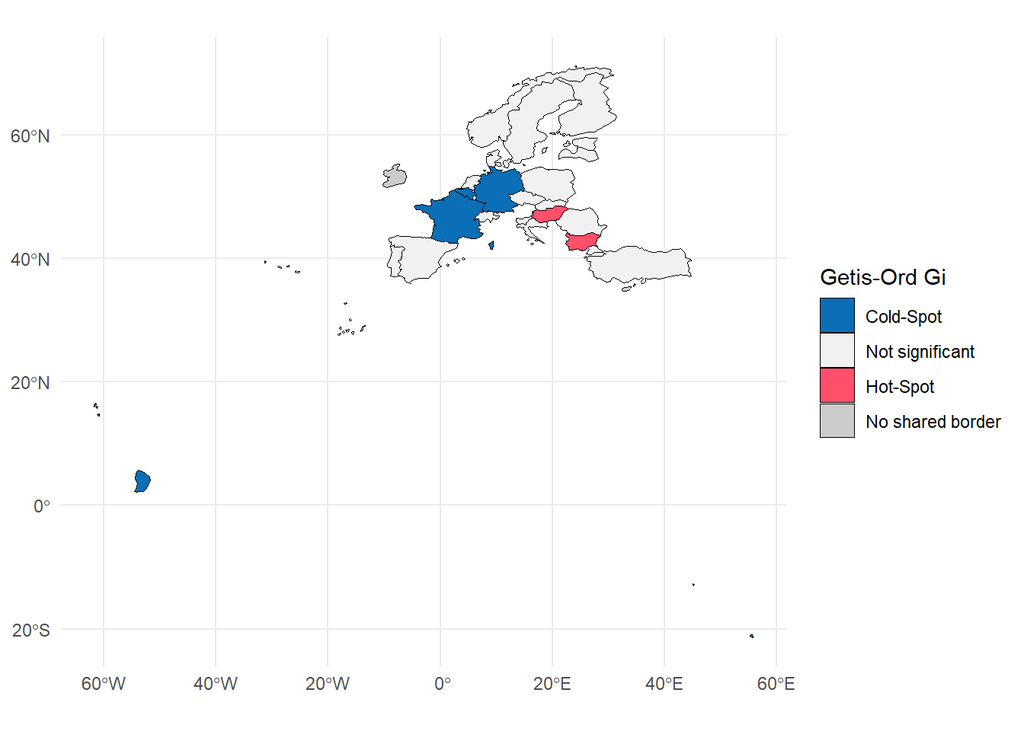

```r
getis <- spdep::localG(geodata$prj_homosexuals, listw = weight_matrix)
groups_getis <- findInterval(getis, c(-1.96, 1.96))
groups_getis <- as.factor(groups_getis)


ggplot() +
  geom_sf(data = geodata, aes(fill = groups_getis), color = "black") +
  scale_fill_manual(
  values = c("#0a6fb6", "#f1f1f1", "#FF4F6B", "grey80"),
  na.value = "grey80",
  labels = c("Cold-Spot", "Not significant", "Hot-Spot", "No shared border"),
  name = "Getis-Ord Gi") +
  theme_minimal()
```